# TP4: Analyse de survie 2 , BINET Thomas

**Important:** Ceci est un document R notebook. En cliquant sur knit vous aurez le choix entre un document html, pdf ou word. Le TP doit être rendu sous la forme d’un fichier NOM_prenom_RegLog.html. Il est à remettre dans moodle. CTRL+Alt+i permet d’ouvrir une cellule de code compilable.

# 1 Tests non-paramétriques.

On travaille sur le dataset `pharmacoSmoking` du package `asaur` dont vous pouvez avoir un aperçu grâce à la fonction `glimpse` (package `tidyverse`, si vous n’avez pas ce package déjà installé préférer les fonctions head et summary).

```r
library(survival)
library(asaur)
#library(tidyverse)
library(ggfortify)
#glimpse(pharmacoSmoking)
```

*1.* Créer une fonction permettant de faire un test du log-rank bilatéral pour la covariable binaire `grp` du dataset `pharmacoSmoking`.

```r
test.log.rank<-function(time,event,delta,group,seuil){
  tmin=min(time)
  tmax=max(time)
  g1=unique(group)[1]
  g2=unique(group)[2]
  event
  temps=tmin:tmax
  sum_Vk=0
  sumd1k=0
  for (t in temps){
    c_k=sum(event==t & delta==0)

    dk=sum(delta[event==t])
    Yk=sum(event>=t)
    d1k=sum(delta[event==t & group==g1])
    Y1k=sum((event[group == g1])>=t)
    d2k=dk-d1k
    Y2k=Yk-Y1k
    Ek=Y1k*dk/Yk
    Vk=((Yk-dk)/(Yk-1))*(dk*Y1k*Y2k/(Yk^2))
    sum_Vk=sum_Vk+Vk
    sumd1k=sumd1k+(d1k-Ek)
  }
  test=(sumd1k^2)/sum_Vk
  cat("ma statistique de test vaut :\n")
  cat(test,"\n")
  ptest=1-pchisq(test,1)
  if(ptest>seuil){
    cat("L'hypothèse H0 : S1(t)=S2(t) est accépté au seuil donné \n")
  }else{
    cat("L'hypothèse H0 : S1(t)=S2(t) est rejeté au seuil donné \n")
  }
  return(test)
}
```

```r
time=pharmacoSmoking$ttr
event=pharmacoSmoking$ttr
delta=pharmacoSmoking$relapse
group=pharmacoSmoking$grp
seuil=0.05
test.log.rank(time,event,delta,group,seuil)
```

```
## ma statistique de test vaut :
## 8.027634
## L'hypothèse H0 : S1(t)=S2(t) est rejeté au seuil donné
```

```
## [1] 8.027634
```

```r
survdiff(Surv(ttr, relapse) ~ grp, data = pharmacoSmoking)
```

```
## Call:
## survdiff(formula = Surv(ttr, relapse) ~ grp, data = pharmacoSmoking)
##
##                  N Observed Expected (O-E)^2/E (O-E)^2/V
## grp=combination 61       37     49.9      3.36      8.03
## grp=patchOnly   64       52     39.1      4.29      8.03
##
##  Chisq= 8  on 1 degrees of freedom, p= 0.005
```

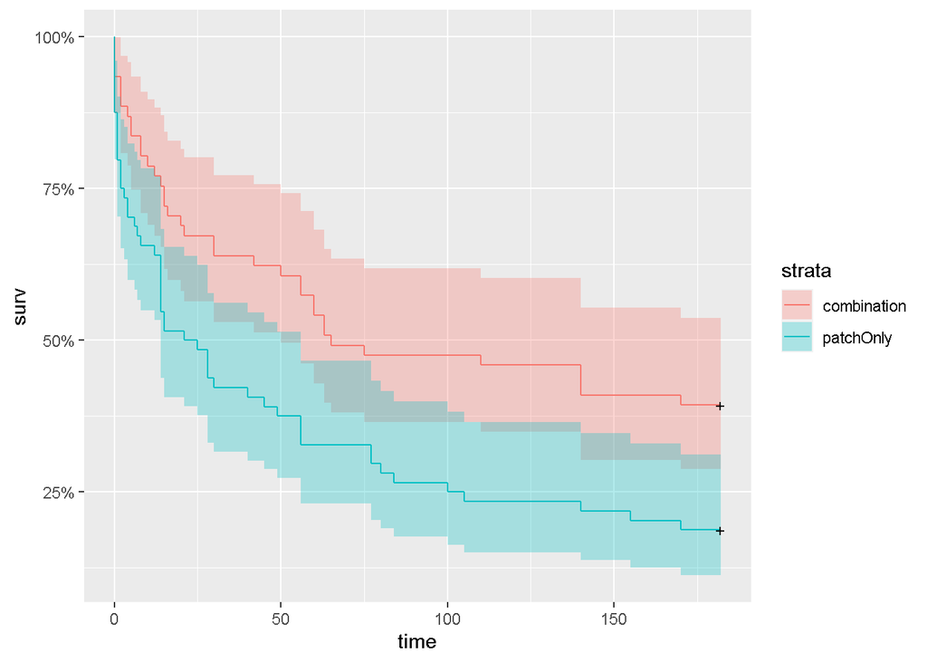

```r
autoplot(survfit(Surv(ttr, relapse) ~ grp, data = pharmacoSmoking))
```

On pourra utiliser la ligne qui suit, donnant les temps ordonnés des événements:

```r
unique(pharmacoSmoking$ttr[order(pharmacoSmoking$ttr)])
```

```
##  [1]   0   1   2   3   4   5   6   7   8  10  12  14  15  16  20  21  25  28  30
## [20]  40  42  45  49  50  56  60  63  65  75  77  80  84 100 105 110 140 155 170
## [39] 182
```

2. Utiliser la fonction `survdiff` pour effectuer un test du $\chi^2$ d’égalité bilatéral au niveau de confiance 0.5% pour la covariable `grp`. Comparer aux résultats obtenus par votre fonction. Pouvez-vous conclure à une différence entre les traitements?

```r
survdiff(Surv(ttr, relapse) ~ grp, data = pharmacoSmoking)
```

```
## Call:
## survdiff(formula = Surv(ttr, relapse) ~ grp, data = pharmacoSmoking)
##
##                  N Observed Expected (O-E)^2/E (O-E)^2/V
## grp=combination 61       37     49.9      3.36      8.03
## grp=patchOnly   64       52     39.1      4.29      8.03
##
##  Chisq= 8  on 1 degrees of freedom, p= 0.005
```

La fonction donne 8.03 pour le Chisq, or la pvalue associé est de 0.004600884 qui est bien inférieur à 0.5%. On peut donc rejetter l’hypothèse H0 associé à l’égalité entre les fonctions probabilités de survie. (exactement comme la fonction d’avant avec la statistique de test 8.027634)

3. A l’aide de l’option `strata`, stratifier les tests menés sur différentes covariables (par exemple `grp`, `employment` ou `ageGroup2` … ). Il est possible de stratifier en fonction de différents covariables (`gender`, `levelSmoking` ou `grp`…). Interpréter les résultats.

```r
survdiff(Surv(ttr, relapse) ~ grp + strata(employment,gender,levelSmoking,ageGroup2), data = pharmacoSmoking)
```

```
## Call:
## survdiff(formula = Surv(ttr, relapse) ~ grp + strata(employment,
##     gender, levelSmoking, ageGroup2), data = pharmacoSmoking)
##
##                  N Observed Expected (O-E)^2/E (O-E)^2/V
## grp=combination 61       37     46.6      1.99      5.74
## grp=patchOnly   64       52     42.4      2.19      5.74
##
##  Chisq= 5.7  on 1 degrees of freedom, p= 0.02
```

4. Y a t-il une différence significative en fonction du genre, de l’âge (ageGroup2) ou des races au seuil de 0.5% (attention, il y a deux covariables différentes pour l’âge)?

# 2 Modéle de Cox

## 2.1 Datasets générés

1. Dans les programmes ci-dessous, la variable temporelle est `t` et les variables explicatives (aussi appelées covariables ou var. dépendantes) sont `x1` et `x2`. La censure est enregistrée par `delta`: 1 pour un événement observé, 0 pour une censure et le suivi dure 1 an maximum. Les données contenues dans les différents `datum` sont-elles générées selon un modèle de Cox ?

```r
set.seed(2)
n=500
x1=rbinom(n,1,0.4)
x2=rbinom(n,1,0.2)
censure=floor(rexp(n,1/2000))
delta=rep(0,n)
t=rep(0,n)
p=0.001
beta=2
#Les jours sont décomptés un à un  par la boucle while et la variable cpt
#chacun étant soumis à un risque instantané.
for(i in 1:n){
  test=0
  cpt=0
  while(test!=1){
    cpt=cpt+1
    test=rbinom(1,1,p*exp(beta*x1[i]/log(cpt+1)))
    if(test==1){t[i]=cpt;delta[i]=1}
    if(cpt>censure[i] || cpt==365){t[i]=cpt ; test=1}
  }
}
datum1=data.frame(x1=x1,x2=x2,delta=delta,t=t)
```

```r
set.seed(2)
n=500
x1=rbinom(n,1,0.4)
x2=rbinom(n,1,0.2)
censure=floor(rexp(n,1/2000))
delta=rep(0,n)
t=rep(0,n)
p=0.001
beta=2
#Les jours sont décomptés un à un  par la boucle while et la variable cpt
#chacun étant soumis à un risque instantané.
for(i in 1:n){
  test=0
  cpt=0
  while(test!=1){
    cpt=cpt+1
    test=rbinom(1,1,p*exp(beta*x1[i]+0.0001*cpt))
    if(test==1){t[i]=cpt;delta[i]=1}
    if(cpt>censure[i] || cpt==365){t[i]=cpt ; test=1}
  }
}
datum2=data.frame(x1=x1,x2=x2,delta=delta,t=t)
```

Les deux programmes génèrent des données de survie avec censure, mais ils ne sont pas tous les deux basés sur un modèle de Cox.

En effet, à cause du log(cpt) dans le datum1, les données généré ne vont pas suivre parfaitement un modèle de Cox contrairement au datum2 qui suit mieux le modèle de Cox.

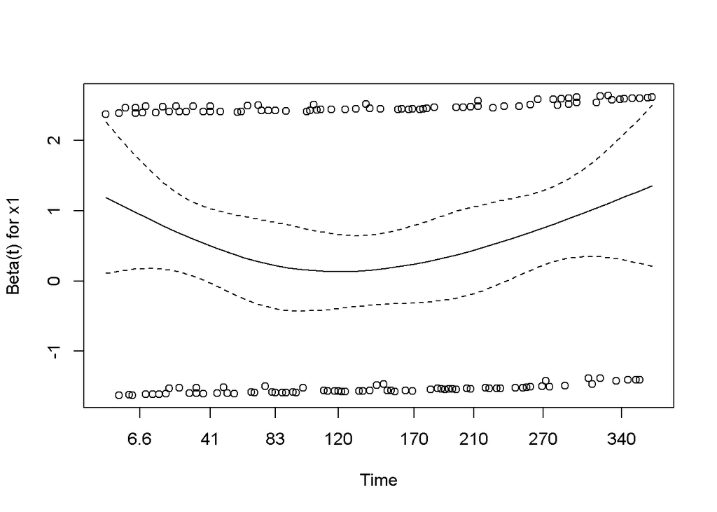

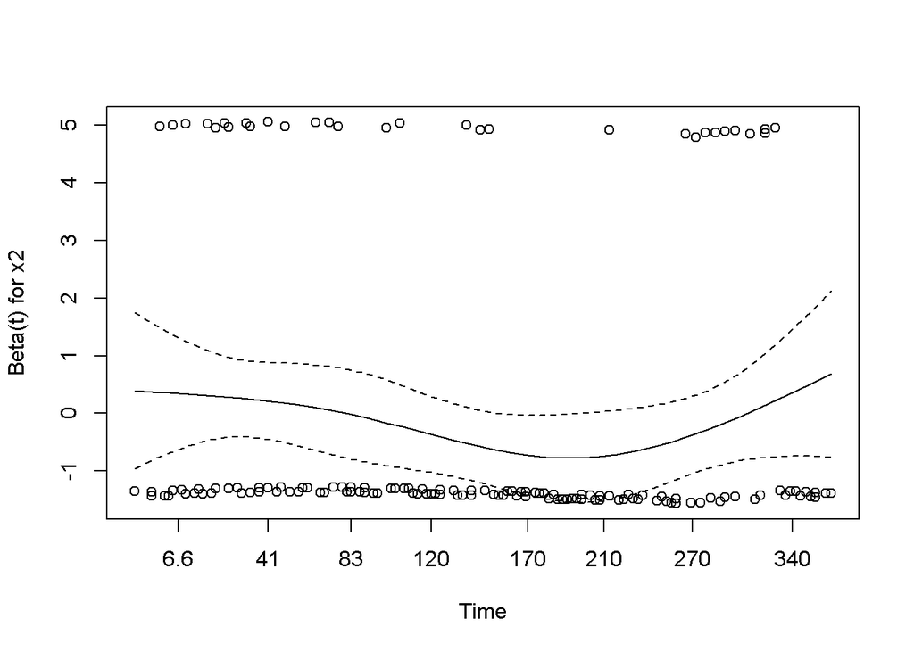

```r
res = cox.zph(coxph(Surv(t,delta) ~ ., data = datum1))
plot(res)
```

```r
print(res)
```

```
##        chisq df    p
## x1     0.246  1 0.62
## x2     0.595  1 0.44
## GLOBAL 0.829  2 0.66
```

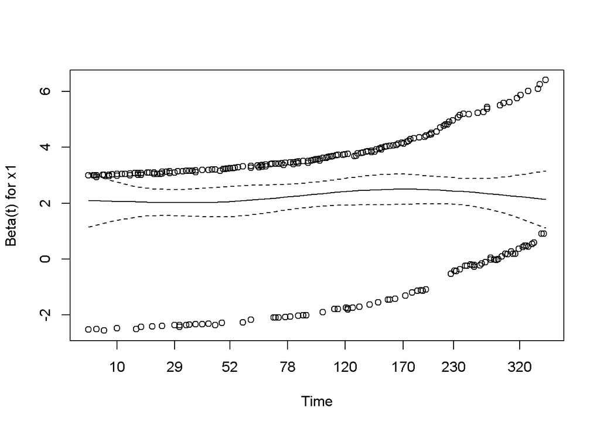

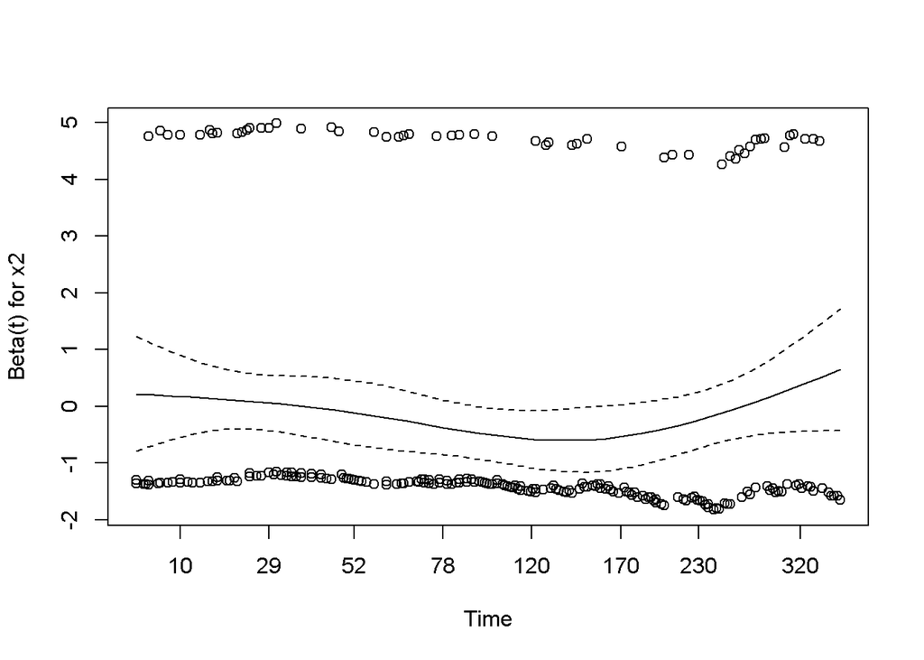

```r
res2 = cox.zph(coxph(Surv(t,delta) ~ ., data = datum2))
plot(res2)
```

```r
print(res2)
```

```
##        chisq df    p
## x1     0.859  1 0.35
## x2     0.115  1 0.73
## GLOBAL 0.979  2 0.61
```

2. Appliquer les lignes suivantes au deux `datum` et interpréter

```r
model<-coxph(Surv(t,delta) ~. , data = datum1)
summary(model)
```

```
## Call:
## coxph(formula = Surv(t, delta) ~ ., data = datum1)
##
##   n= 500, number of events= 153
##
##       coef exp(coef) se(coef)      z Pr(>|z|)
## x1  0.5601    1.7509   0.1619  3.459 0.000543 ***
## x2 -0.1520    0.8590   0.2037 -0.746 0.455623
## ---
## Signif. codes:  0 '***' 0.001 '**' 0.01 '*' 0.05 '.' 0.1 ' ' 1
##
##    exp(coef) exp(-coef) lower .95 upper .95
## x1     1.751     0.5711    1.2747     2.405
## x2     0.859     1.1641    0.5762     1.281
##
## Concordance= 0.576  (se = 0.021 )
## Likelihood ratio test= 12.57  on 2 df,   p=0.002
## Wald test            = 12.6  on 2 df,   p=0.002
## Score (logrank) test = 12.92  on 2 df,   p=0.002
```

```r
rat=1.751+0.859
1.751/rat
```

```
## [1] 0.6708812
```

```r
model<-coxph(Surv(t,delta) ~. , data = datum2)
summary(model)
```

```
## Call:
## coxph(formula = Surv(t, delta) ~ ., data = datum2)
##
##   n= 500, number of events= 272
##
##       coef exp(coef) se(coef)      z Pr(>|z|)
## x1  2.2421    9.4134   0.1423 15.756   <2e-16 ***
## x2 -0.1462    0.8640   0.1502 -0.973     0.33
## ---
## Signif. codes:  0 '***' 0.001 '**' 0.01 '*' 0.05 '.' 0.1 ' ' 1
##
##    exp(coef) exp(-coef) lower .95 upper .95
## x1     9.413     0.1062    7.1223     12.44
## x2     0.864     1.1574    0.6436      1.16
##
## Concordance= 0.738  (se = 0.013 )
## Likelihood ratio test= 281.5  on 2 df,   p=<2e-16
## Wald test            = 248.9  on 2 df,   p=<2e-16
## Score (logrank) test = 333.6  on 2 df,   p=<2e-16
```

3. Compléter le code pour générer un dataframe `datum3` selon le modèle de Cox avec deux variables explicatives binaires `x1` et `x2` suivant:
   $$\lambda(t\mid Z) =\lambda_0(t)\exp(0.5X_1\times
   X_2),$$
   avec
   $$\lambda_0(t)=0.002/\log(t+1),$$
   pour $t$ entier dans l’ensemble $\{0,\ldots, 365\}.$ La censure sera générée comme pour `datum` 1 et 2.

```r
set.seed(4)
n=500
x1=rbinom(n,1,0.5)
x2=rbinom(n,1,0.5)
censure=floor(rexp(n,1/2000))
delta=rep(0,n)
t=rep(0,n)
p=0.002
beta=0.5
for(i in 1:n){
  lambda0=p/log(i+1)
  lambda=lambda0*exp(beta*x1[i]*x2[i])
  T=rpois(1,lambda)
  if(T<=censure[i]){
    delta[i]=1
    t[i]=T
  } else {
    delta[i]=0
    t[i]=censure[i]
  }
}
datum3=data.frame(x1=x1,x2=x2,delta=delta,t=t)
model<-coxph(Surv(t,delta) ~ x1*x2 , data = datum3)
summary(model)
```

```
## Call:
## coxph(formula = Surv(t, delta) ~ x1 * x2, data = datum3)
##
##   n= 500, number of events= 500
##
##            coef exp(coef)  se(coef) z Pr(>|z|)
## x1    8.948e-17 1.000e+00 1.222e-01 0        1
## x2    2.636e-15 1.000e+00 1.243e-01 0        1
## x1:x2 6.179e-15 1.000e+00 1.796e-01 0        1
##
##       exp(coef) exp(-coef) lower .95 upper .95
## x1            1          1    0.7871     1.271
## x2            1          1    0.7837     1.276
## x1:x2         1          1    0.7032     1.422
##
## Concordance= NaN  (se = NaN )
## Likelihood ratio test= 0  on 3 df,   p=1
## Wald test            = 0  on 3 df,   p=1
## Score (logrank) test = 0  on 3 df,   p=1
```

4. Appliquer le modèle de Cox à `datum3` avec ou sans interaction.

## 2.2 Le dataset pharmacoSmoking

1. ’A l’aide de la fonction `coxph`, ajustez un modèle de Cox sur toutes les covariables. Quels problèmes voyez-vous dans cette procédure. Ajustez un modèle de Cox sur un ensemble de covariable ne posant plus ce problème.

   ```r
   model<-coxph(Surv(ttr,relapse)~ .,data=pharmacoSmoking)
   summary(model)
   ```

   ```
   ## Call:
   ## coxph(formula = Surv(ttr, relapse) ~ ., data = pharmacoSmoking)
   ##
   ##   n= 125, number of events= 89
   ##
   ##                         coef  exp(coef)   se(coef)      z Pr(>|z|)
   ## id                 4.891e-03  1.005e+00  2.927e-03  1.671  0.09474 .
   ## grppatchOnly       6.381e-01  1.893e+00  2.231e-01  2.860  0.00423 **
   ## age               -4.831e-02  9.528e-01  3.232e-02 -1.495  0.13495
   ## genderMale         5.369e-03  1.005e+00  2.549e-01  0.021  0.98319
   ## racehispanic      -6.079e-01  5.445e-01  5.300e-01 -1.147  0.25137
   ## raceother         -1.361e+00  2.563e-01  1.063e+00 -1.281  0.20016
   ## racewhite         -3.738e-01  6.881e-01  2.600e-01 -1.438  0.15040
   ## employmentother    7.102e-01  2.034e+00  2.883e-01  2.464  0.01375 *
   ## employmentpt       5.360e-01  1.709e+00  3.475e-01  1.543  0.12290
   ## yearsSmoking       9.193e-03  1.009e+00  1.950e-02  0.471  0.63736
   ## levelSmokinglight -1.258e-01  8.818e-01  2.736e-01 -0.460  0.64557
   ## ageGroup250+       9.159e-01  2.499e+00  1.240e+00  0.739  0.46016
   ## ageGroup435-49     3.574e-01  1.430e+00  4.953e-01  0.722  0.47050
   ## ageGroup450-64    -9.821e-01  3.745e-01  6.111e-01 -1.607  0.10804
   ## ageGroup465+              NA         NA  0.000e+00     NA       NA
   ## priorAttempts      2.645e-04  1.000e+00  1.106e-03  0.239  0.81097
   ## longestNoSmoke    -3.682e-05  1.000e+00  1.277e-04 -0.288  0.77318
   ## ---
   ## Signif. codes:  0 '***' 0.001 '**' 0.01 '*' 0.05 '.' 0.1 ' ' 1
   ##
   ##                   exp(coef) exp(-coef) lower .95 upper .95
   ## id                   1.0049     0.9951   0.99915     1.011
   ## grppatchOnly         1.8930     0.5283   1.22248     2.931
   ## age                  0.9528     1.0495   0.89435     1.015
   ## genderMale           1.0054     0.9946   0.61006     1.657
   ## racehispanic         0.5445     1.8365   0.19271     1.539
   ## raceother            0.2563     3.9014   0.03193     2.057
   ## racewhite            0.6881     1.4533   0.41339     1.145
   ## employmentother      2.0345     0.4915   1.15633     3.579
   ## employmentpt         1.7092     0.5851   0.86503     3.377
   ## yearsSmoking         1.0092     0.9908   0.97139     1.049
   ## levelSmokinglight    0.8818     1.1341   0.51581     1.507
   ## ageGroup250+         2.4990     0.4002   0.21990    28.399
   ## ageGroup435-49       1.4296     0.6995   0.54158     3.774
   ## ageGroup450-64       0.3745     2.6700   0.11307     1.241
   ## ageGroup465+             NA         NA        NA        NA
   ## priorAttempts        1.0003     0.9997   0.99810     1.002
   ## longestNoSmoke       1.0000     1.0000   0.99971     1.000
   ##
   ## Concordance= 0.682  (se = 0.03 )
   ## Likelihood ratio test= 34.9  on 16 df,   p=0.004
   ## Wald test            = 32.25  on 16 df,   p=0.009
   ## Score (logrank) test = 33.91  on 16 df,   p=0.006
   ```

   ```r
   model2<-coxph(Surv(ttr,relapse)~ id+grp+employment+levelSmoking,data=pharmacoSmoking)
   summary(model2)
   ```

   ```
   ## Call:
   ## coxph(formula = Surv(ttr, relapse) ~ id + grp + employment +
   ##     levelSmoking, data = pharmacoSmoking)
   ##
   ##   n= 125, number of events= 89
   ##
   ##                       coef exp(coef) se(coef)     z Pr(>|z|)
   ## id                0.004765  1.004777 0.002597 1.835  0.06652 .
   ## grppatchOnly      0.679353  1.972600 0.219589 3.094  0.00198 **
   ## employmentother   0.294330  1.342227 0.239444 1.229  0.21899
   ## employmentpt      0.501200  1.650701 0.326938 1.533  0.12527
   ## levelSmokinglight 0.107564  1.113562 0.234179 0.459  0.64600
   ## ---
   ## Signif. codes:  0 '***' 0.001 '**' 0.01 '*' 0.05 '.' 0.1 ' ' 1
   ##
   ##                   exp(coef) exp(-coef) lower .95 upper .95
   ## id                    1.005     0.9952    0.9997     1.010
   ## grppatchOnly          1.973     0.5069    1.2827     3.034
   ## employmentother       1.342     0.7450    0.8395     2.146
   ## employmentpt          1.651     0.6058    0.8697     3.133
   ## levelSmokinglight     1.114     0.8980    0.7037     1.762
   ##
   ## Concordance= 0.618  (se = 0.03 )
   ## Likelihood ratio test= 14.53  on 5 df,   p=0.01
   ## Wald test            = 14.17  on 5 df,   p=0.01
   ## Score (logrank) test = 14.56  on 5 df,   p=0.01
   ```

   ```r
   library(MASS)
   step.model <- stepAIC(model,trace = FALSE)
   coef(step.model)
   ```

   ```
   ##              id    grppatchOnly             age employmentother    employmentpt
   ##     0.004618849     0.631219777    -0.042781113     0.632057438     0.518621541
   ##  ageGroup435-49  ageGroup450-64    ageGroup465+
   ##     0.492297842     0.106280721     1.157463120
   ```

3. Représenter la fonction de survie pour les covariables correspondants aux 4 premiers patients et pour le modèle optimisé par la fonction `stepAIC` (1 courbe pour chaque patient). On utilisera L’estimateur du risque cumulé de Breslow pour estimer la fonction de survie (slide 27).
4. Interpréter les lignes de code suivantes:

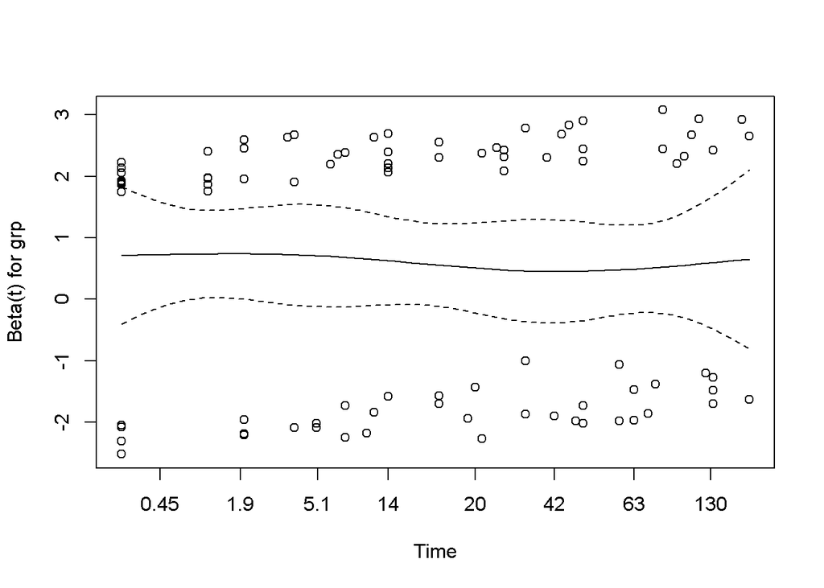

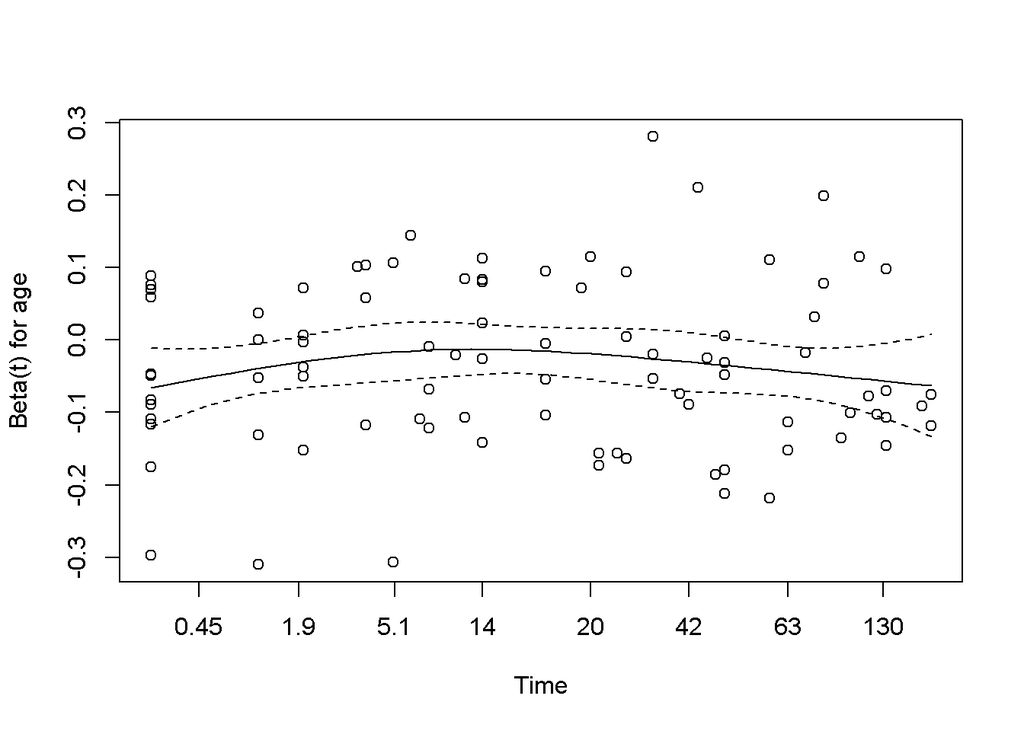

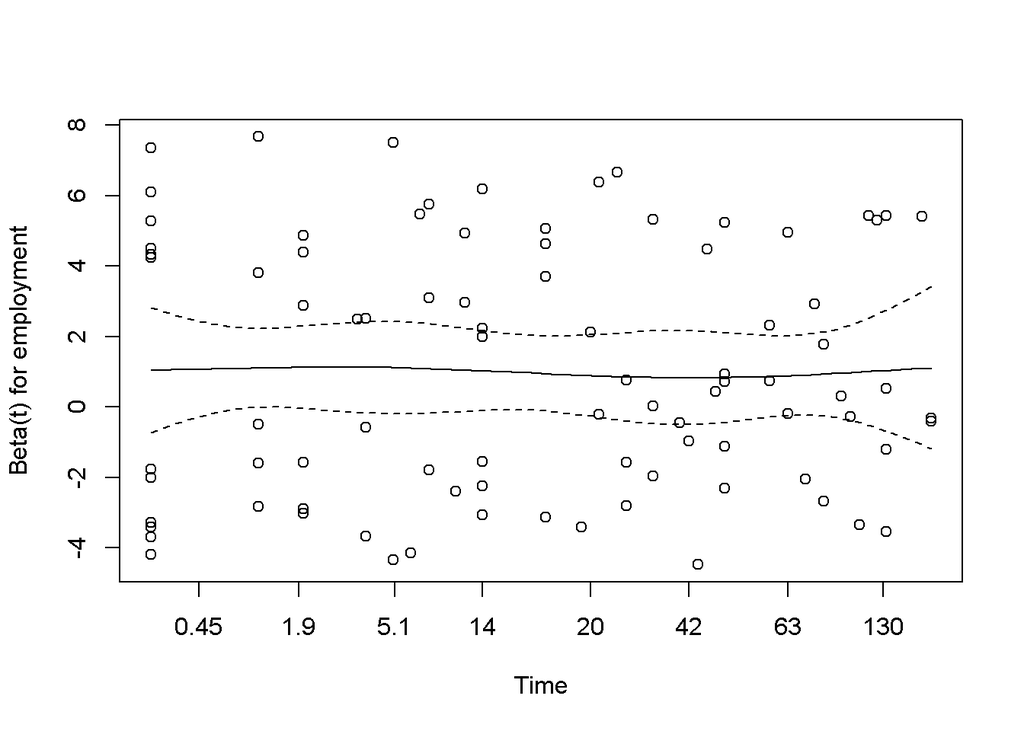

```r
res = cox.zph(coxph(Surv(ttr,relapse) ~ grp + age + employment, data = pharmacoSmoking))
plot(res)
```

```r
print(res)
```

```
##               chisq df    p
## grp        0.116710  1 0.73
## age        0.000826  1 0.98
## employment 0.892067  2 0.64
## GLOBAL     1.111925  4 0.89
```

Le bloc de code suivant réalisent le test de l’hypothèse de proportionnalité des risques de Cox pour le modèle de régression `coxph` spécifié avec une survie `Surv(ttr,relapse)` en fonction de trois variables explicatives `grp`, `age` et `employment`. La fonction `cox.zph` calcule la statistique de Schoenfeld pour chaque variable explicative, qui permet de tester si l’effet de chaque variable sur le risque de l’événement est constant au cours du temps.